# IE360 HW1

Mehmet Barış Cankır

2024-04-05

# Introduction

The aim of this project is to analyze and draw conclusions from the following data sets that are taken from the Central Bank of the Republic of Turkey and create time series regression models for each one of them. The chosen data sets are as follows:

1- “Tedavüldeki Banknotların Kupür Dağılımı (Tutar TL)(Aylık) / Tedavüldeki Banknotlar Toplam (Tutar TL)”

2- “Temel işgücü göstergeleri (Bin Kişi - 15+ yaş)(Aylık) / İşsizlik Oranı (%)”

The search is to see if there is if we can find any correlation between the above data sets and other data sets seperately.

For the total value of the banknotes in circulation of Turkish Lira, we will look for consumer price index, USD/TL exchange rate, and Google Trends data of search for the word “enflasyon” (inflation in Turkish). All data is in between the years 2018 and 2024, and provided monthly.

# Banknotes in Circulation

## Data Manipulation and Visualization

We import the needed libraries and the data we will perform the analysis on.

```r
require(GGally)
library(lmtest)
library(readxl)
library(ggplot2)
library(stats)
library(tseries)
library(forecast)
library(xts)
require(openxlsx)
require(data.table)
require(skimr)
require(GGally)
require(ggcorrplot)
library(dplyr)

banknotes <- read_excel("/Users/baris/Desktop/Banknotes.xlsx")
inflation <- read_excel("/Users/baris/Desktop/Inflation.xlsx")
tufe <- read_excel("/Users/baris/Desktop/TÜFE.xlsx")
usd_tl <-read_excel("/Users/baris/Desktop/USD-TL.xlsx")
```

Since the data imported has a different data type for Date, we change the data type to date.

```r
banknotes$Date <- as.Date(banknotes$Date)
inflation$Date <- as.Date(inflation$Date)
usd_tl$Date <- as.Date(usd_tl$Date)
tufe$Date <- as.Date(tufe$Date)
```

We combine all in a single merged data set synced by date.

```r
combined_banknotes <- merge(banknotes, inflation, by="Date")
combined_banknotes <- merge(combined_banknotes, tufe, by="Date")
combined_banknotes <- merge(combined_banknotes, usd_tl, by="Date")
```

We should observe the plots of each additional data with the amount of circulating banknotes.

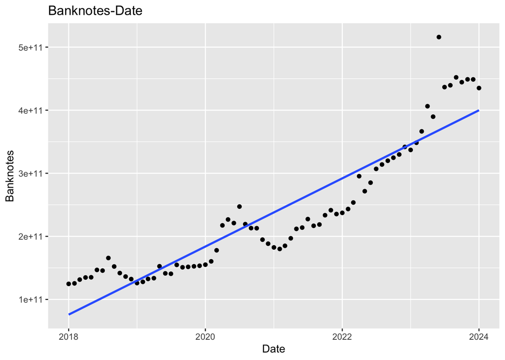

```r
ggplot(data=combined_banknotes, aes(x=Date, y=Banknotes)) + geom_point() + labs(title= "Banknotes-Date") + geom_smooth(method="lm", se=FALSE)
```

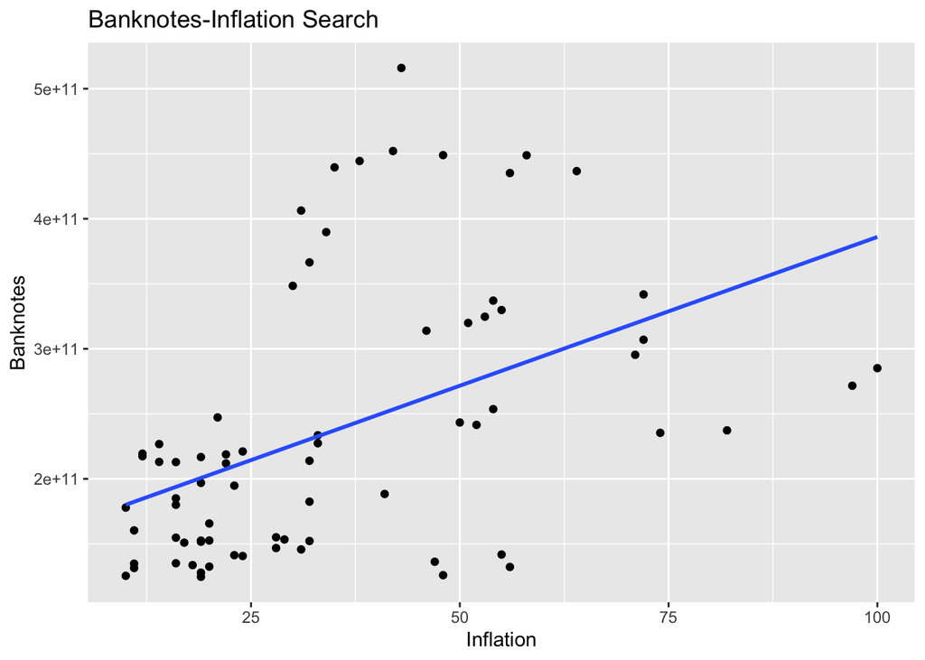

```r
ggplot(data=combined_banknotes, aes(x=Inflation, y=Banknotes)) + geom_point() + labs(title= "Banknotes-Inflation Search") + geom_smooth(method="lm", se=FALSE)
```

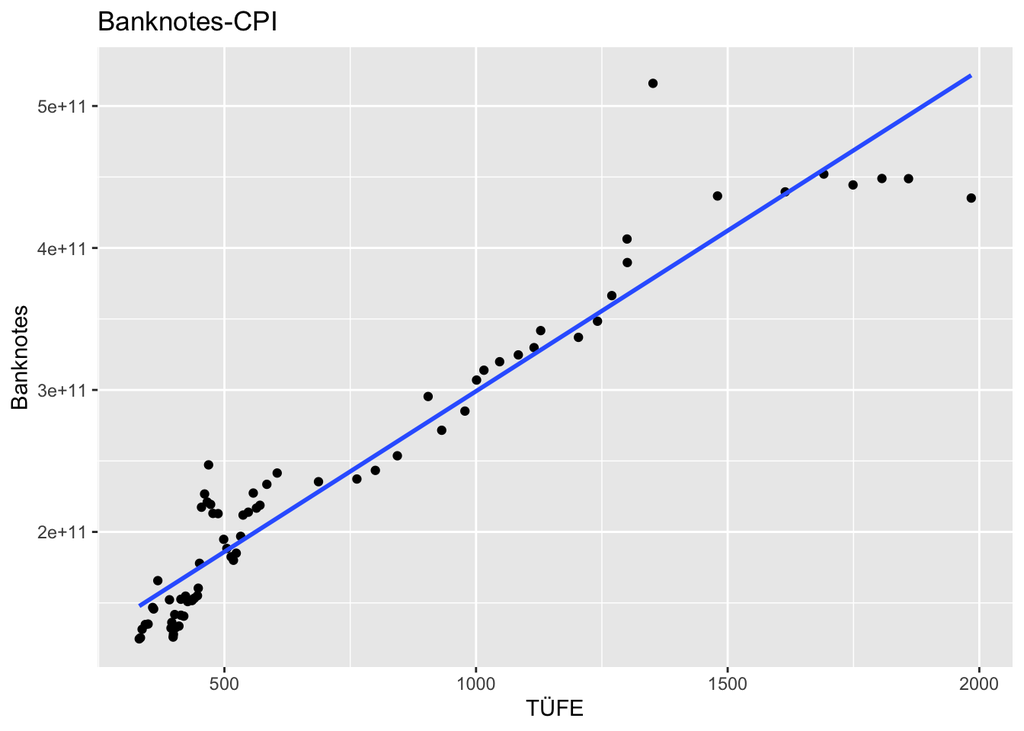

```r
ggplot(data=combined_banknotes, aes(x=TÜFE, y=Banknotes)) + geom_point() + labs(title= "Banknotes-CPI") + geom_smooth(method="lm", se=FALSE)
```

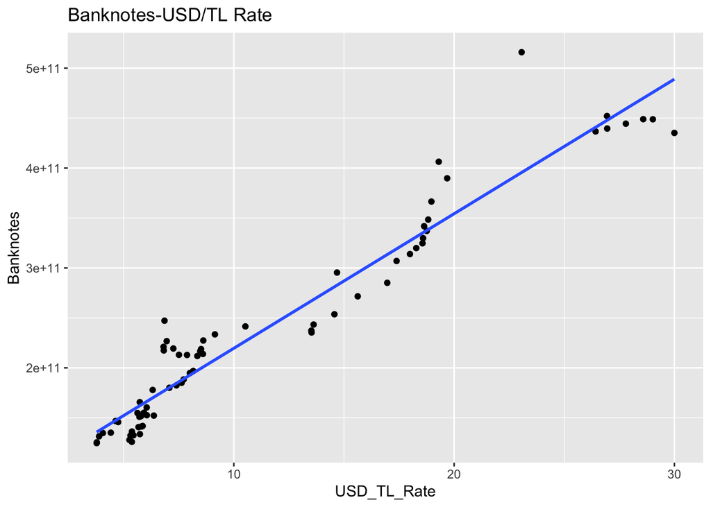

```r
ggplot(data=combined_banknotes, aes(x=USD_TL_Rate, y=Banknotes)) + geom_point() + labs(title= "Banknotes-USD/TL Rate") + geom_smooth(method="lm", se=FALSE)
```

We can see that it is highly likely to create a good model for banknotes with the others. We can also check for a total paired correlation table with ggpairs.

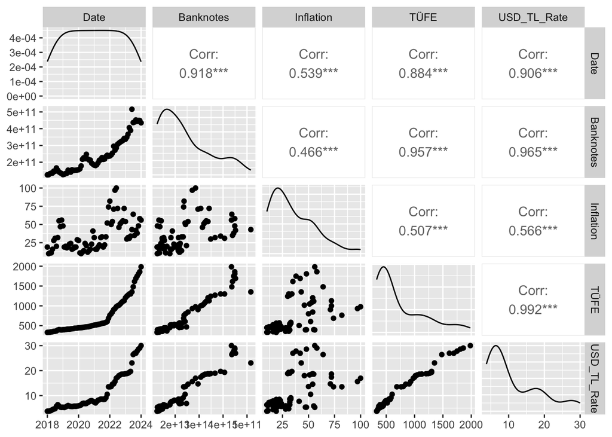

```r
ggpairs(data.frame(combined_banknotes))
```

## Time Series Regression

We should create a time series data and add seasonality dummy variable to our data set.

```r
ts_data <- ts(combined_banknotes$Banknotes, frequency = 12)
seasonality <- seasonaldummy(ts_data)
combined_banknotes <- cbind(combined_banknotes, seasonality)
```

We should create a model where we give the decided data as the predictors.

```r
banknotes_model <- lm(Banknotes ~ Date + Inflation + seasonality + TÜFE + USD_TL_Rate, combined_banknotes)
```

We can check out the relevant plots to see if it seems to be a good model.

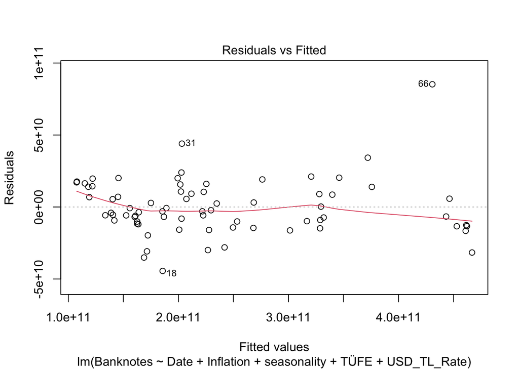

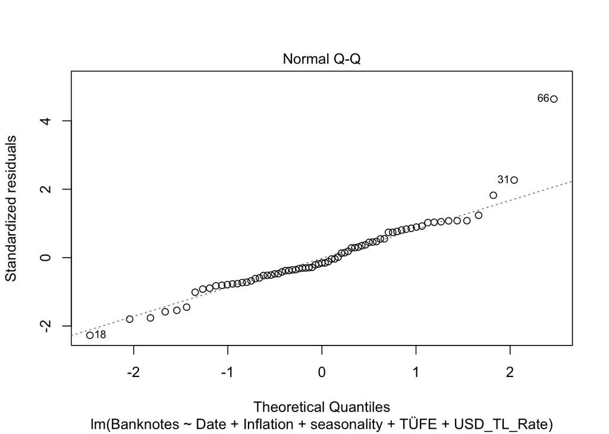

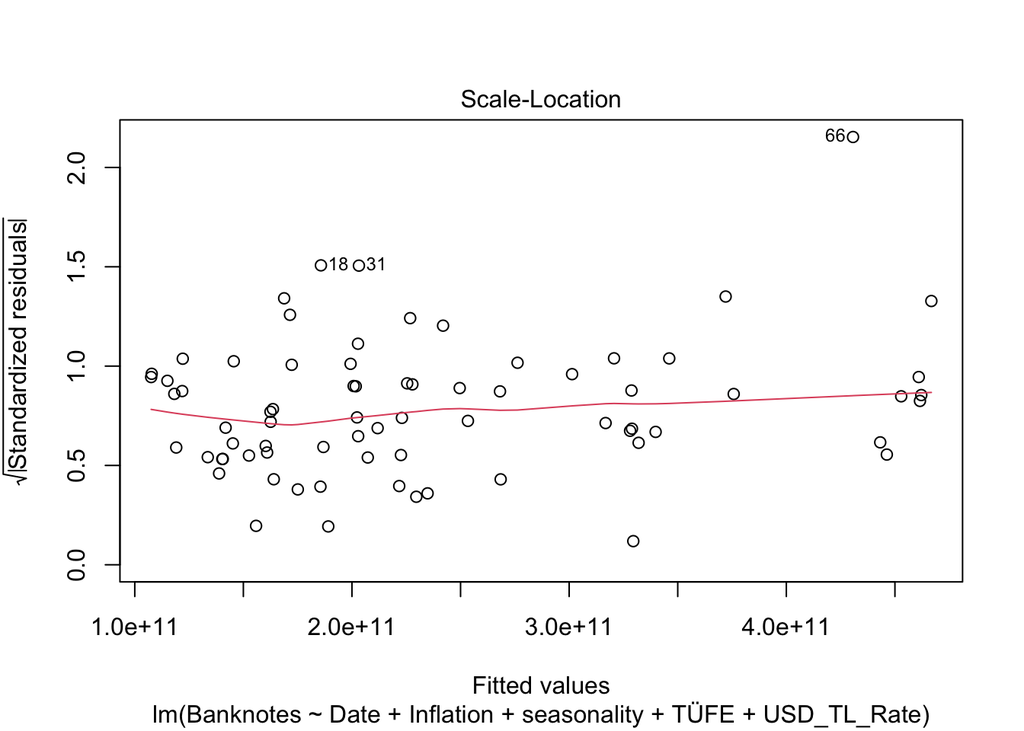

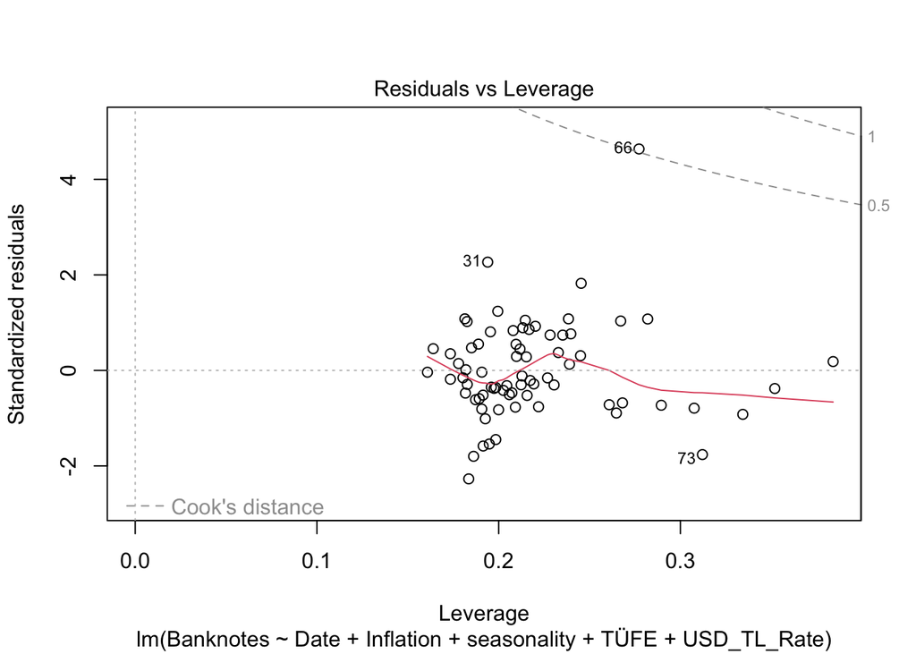

```r
plot(banknotes_model)
```

Given plots seems to be good enough. We can check for the summary.

```r
summary(banknotes_model)
```

```
##
## Call:
## lm(formula = Banknotes ~ Date + Inflation + seasonality + TÜFE +
##     USD_TL_Rate, data = combined_banknotes)
##
## Residuals:
##        Min         1Q     Median         3Q        Max
## -4.439e+10 -1.155e+10 -3.026e+09  1.071e+10  8.525e+10
##
## Coefficients:
##                  Estimate Std. Error t value Pr(>|t|)
## (Intercept)    -6.430e+11  1.762e+11  -3.649 0.000573 ***
## Date            4.181e+07  9.822e+06   4.256 7.84e-05 ***
## Inflation      -7.853e+08  2.094e+08  -3.751 0.000414 ***
## seasonalityJan -7.400e+09  1.222e+10  -0.606 0.547215
## seasonalityFeb -1.552e+10  1.334e+10  -1.163 0.249618
## seasonalityMar -9.931e+09  1.332e+10  -0.746 0.458996
## seasonalityApr  1.047e+10  1.315e+10   0.797 0.428937
## seasonalityMay  1.026e+10  1.288e+10   0.797 0.428919
## seasonalityJun  2.790e+10  1.277e+10   2.185 0.032979 *
## seasonalityJul  1.519e+10  1.295e+10   1.173 0.245562
## seasonalityAug -2.178e+09  1.410e+10  -0.154 0.877801
## seasonalitySep -2.176e+09  1.347e+10  -0.162 0.872258
## seasonalityOct -1.425e+09  1.301e+10  -0.110 0.913166
## seasonalityNov -3.017e+09  1.276e+10  -0.236 0.813910
## TÜFE           -2.981e+07  6.404e+07  -0.465 0.643355
## USD_TL_Rate     1.319e+10  4.260e+09   3.096 0.003039 **
## ---
## Signif. codes:  0 '***' 0.001 '**' 0.01 '*' 0.05 '.' 0.1 ' ' 1
##
## Residual standard error: 2.163e+10 on 57 degrees of freedom
## Multiple R-squared:  0.9657, Adjusted R-squared:  0.9567
## F-statistic: 107.1 on 15 and 57 DF,  p-value: < 2.2e-16
```

R^2, adjusted R^2, F-stat and p-value seems satisfying. We can continue with BG test to see if there is something wrong with the model.

```r
bgtest(banknotes_model)
```

```
##
##  Breusch-Godfrey test for serial correlation of order up to 1
##
## data:  banknotes_model
## LM test = 17.617, df = 1, p-value = 2.701e-05
```

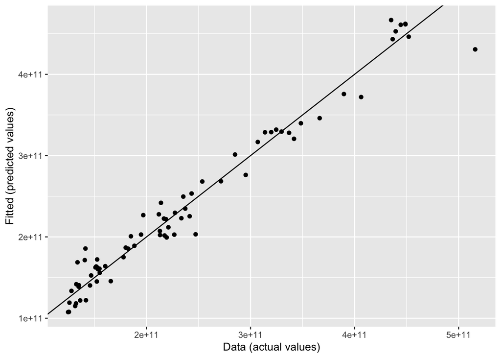

```r
banknotes_data=data.table(Actual = combined_banknotes$Banknotes, Fitted=fitted(banknotes_model))
ggplot(banknotes_data,aes(x=Actual, y=Fitted)) + geom_point() + ylab("Fitted (predicted values)") + xlab("Data (actual values)") + geom_abline(intercept=0, slope=1)
```

## Conclusion

# Unemployment

## Data Manipulation and Visualization

```r
unemployment <- read_excel("/Users/baris/desktop/Unemployment.xlsx")
jobsearch <- read_excel("/Users/baris/desktop/JobSearch.xlsx")
working_population <- read_excel("/Users/baris/desktop/Working Population.xlsx")
combined_unemployment <- merge(unemployment, jobsearch, by="Date")
combined_unemployment <- merge(combined_unemployment, working_population, by="Date")
```

Since the data imported has a different data type for Date, we change the data type to date.

```r
combined_unemployment$Date <- as.Date(combined_unemployment$Date)
```

Let’s check the plots to see if we can detect a good correlation between the chosen data sets.

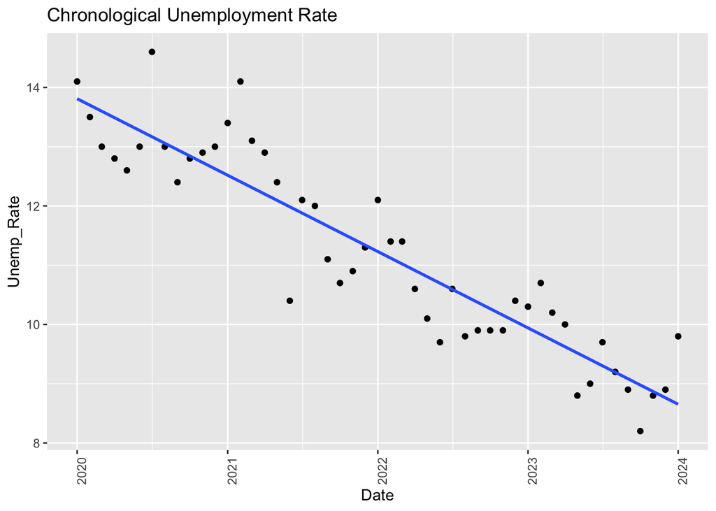

[figure not shown]

[figure not shown]

We can see that it is highly likely to create a good model for uneployment with the others. We can also check for a total paired correlation table with ggpairs.

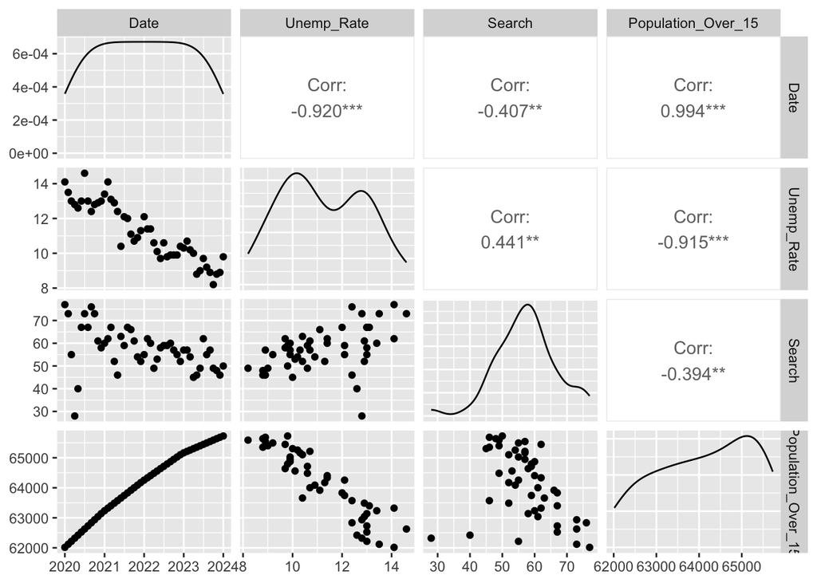

```r
ggpairs(combined_unemployment)
```

Here, we can clearly see that especially date (trend) and population over 15 years old data gives the highest correlation.

## Time Series Regression

We should create a time series data and add seasonality dummy variable to our data set.

```r
ts_data <- ts(combined_unemployment$Unemp_Rate, frequency = 12)
seasonality <- seasonaldummy(ts_data)
combined_unemployment <- cbind(combined_unemployment, seasonality)
```

We should create a model where we give the decided data as the predictors.

```r
unemployment_model <- lm(Unemp_Rate ~ Search + Date + seasonality + Population_Over_15, combined_unemployment)
```

We can check out the relevant plots to see if it seems to be a good model.

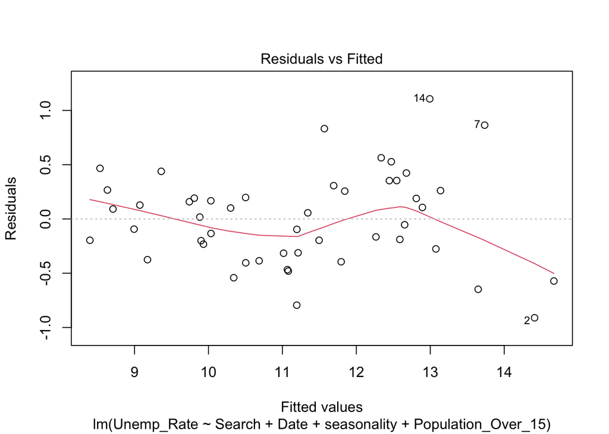

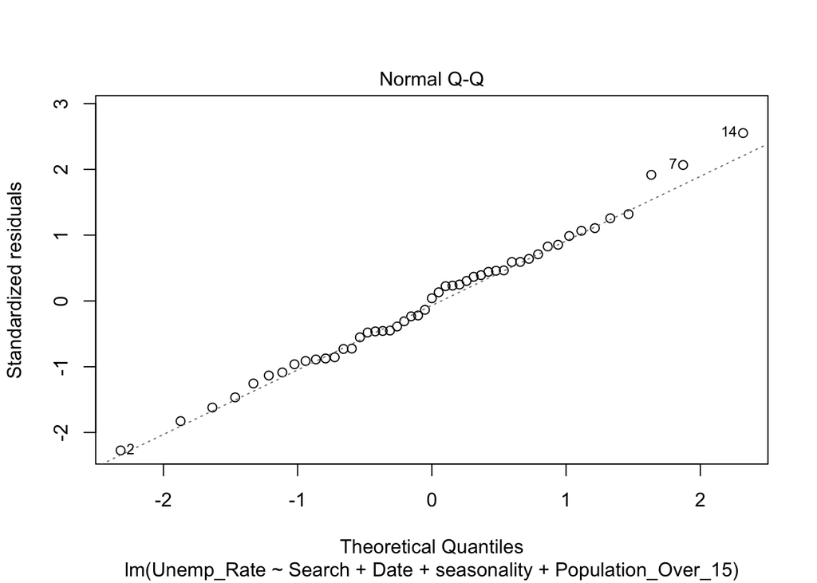

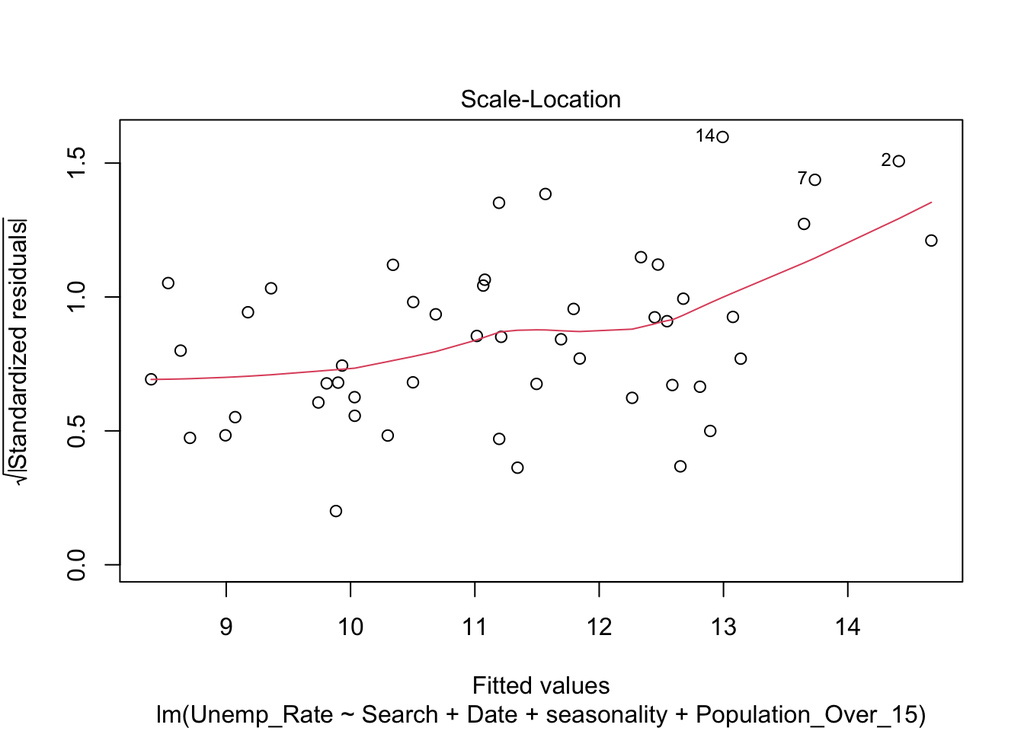

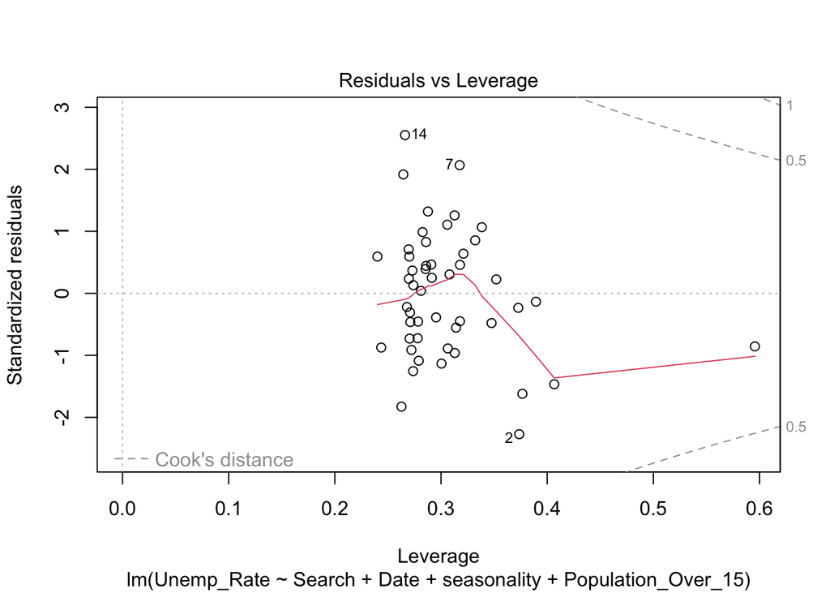

```r
plot(unemployment_model)
```

Given plots seems to be good enough. We can check for the summary.

```r
summary(unemployment_model)
```

```
##
## Call:
## lm(formula = Unemp_Rate ~ Search + Date + seasonality + Population_Over_15,
##     data = combined_unemployment)
##
## Residuals:
##      Min       1Q   Median       3Q      Max
## -0.91057 -0.31174  0.01728  0.26151  1.10699
##
## Coefficients:
##                      Estimate Std. Error t value Pr(>|t|)
## (Intercept)         7.300e+01  9.621e+00   7.588 8.16e-09 ***
## Search              1.925e-02  1.371e-02   1.404  0.16939
## Date               -3.228e-03  1.584e-03  -2.038  0.04935 *
## seasonalityJan      3.912e-01  3.546e-01   1.103  0.27777
## seasonalityFeb      3.090e-01  3.806e-01   0.812  0.42248
## seasonalityMar     -1.172e-02  3.661e-01  -0.032  0.97465
## seasonalityApr      3.837e-02  3.900e-01   0.098  0.92219
## seasonalityMay     -5.162e-01  3.755e-01  -1.375  0.17826
## seasonalityJun     -1.115e+00  3.673e-01  -3.035  0.00459 **
## seasonalityJul      1.316e-01  3.833e-01   0.343  0.73345
## seasonalityAug     -4.927e-01  3.786e-01  -1.301  0.20189
## seasonalitySep     -8.689e-01  3.937e-01  -2.207  0.03416 *
## seasonalityOct     -8.541e-01  3.724e-01  -2.294  0.02812 *
## seasonalityNov     -4.215e-01  3.594e-01  -1.173  0.24899
## Population_Over_15 -2.018e-05  5.990e-04  -0.034  0.97331
## ---
## Signif. codes:  0 '***' 0.001 '**' 0.01 '*' 0.05 '.' 0.1 ' ' 1
##
## Residual standard error: 0.5064 on 34 degrees of freedom
## Multiple R-squared:  0.9347, Adjusted R-squared:  0.9079
## F-statistic: 34.79 on 14 and 34 DF,  p-value: 4.863e-16
```

R^2, adjusted R^2, F-stat and p-value seems satisfying. We can continue with BG test to see if there is something wrong with the model.

```r
bgtest(unemployment_model)
```

```
##
##  Breusch-Godfrey test for serial correlation of order up to 1
##
## data:  unemployment_model
## LM test = 6.5428, df = 1, p-value = 0.01053
```

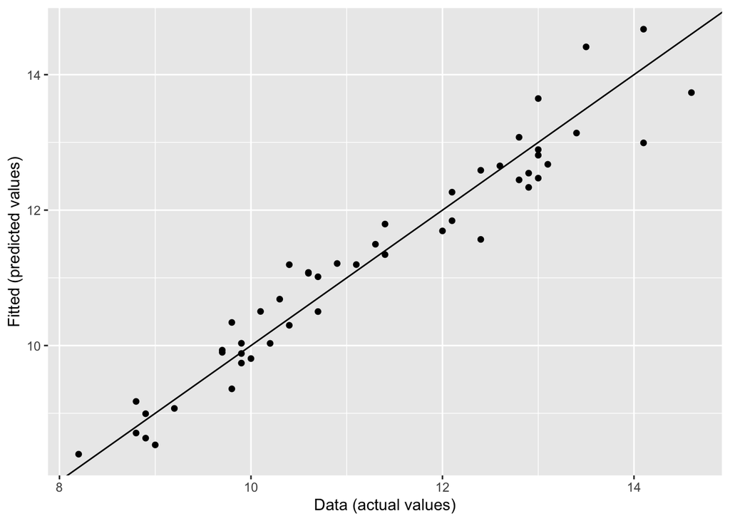

```r
unemp_data=data.table(Actual = combined_unemployment$Unemp_Rate, Fitted=fitted(unemployment_model))
ggplot(unemp_data,aes(x=Actual, y=Fitted)) + geom_point() + ylab("Fitted (predicted values)") + xlab("Data (actual values)") + geom_abline(intercept=0, slope=1)
```